# 03_teoría_cnn

#### Nombre: **Teoría de las CNN**

#### Autores: *Sergio Cañón Laiz y Ignacio Ruiz de Zuazu Echavarría*

#### 15/01/2021

# Introducción

Con el fin de no se haga repetitivo a lo largo de cada notebook la explicación del uso de determinados parámetros en los modelos, el objetivo del actual notebook es el de desarrollar una expliación téorica de las CNN, incluyendo las funciones de activación pérdida y las características de las diferentes capas, que se aplicarán en los siguientes modelos.

# Capas o *Layers*

El componente básico de las redes neuronales es la capa, un módulo de procesamiento de datos que puede pensar en un filtro de datos. Algunos datos entran y salen de una forma más útil. formar. Específicamente, las capas extraen representaciones a partir de los datos que se les ingresan; con suerte, representaciones que son más significativas para el problema en cuestión. La mayoría de el aprendizaje profundo consiste en encadenar capas simples que implementarán un formulario de destilación progresiva de datos. Un modelo de aprendizaje profundo es como un tamiz para el procesamiento de datos, compuesto por una sucesión de filtros de datos cada vez más refinados: las capas.

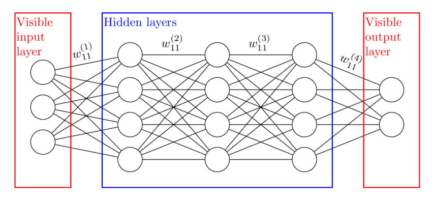

## Conv2D

Son muy usadas en el procesamiento de imagenes, las capas de convolución aprenden patrones locales.

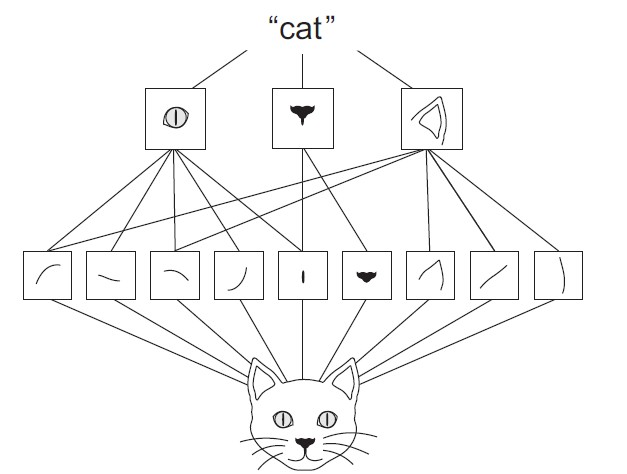

Están definidas por dos parámetros:

- Tamaño del kernel: nosotros usaremos 3x3 o 2x2 dependiendo de la precisión que necesitemos.
- Profundidad de feature-map: El número de filtros calculados por la convolución. Al igual que en anterior parámetro usraemos 256 o 128.

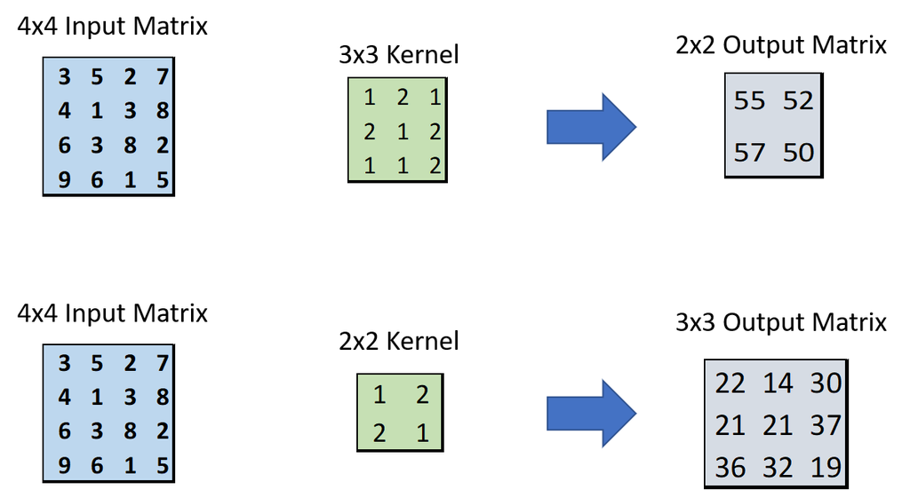

## MaxPooling2D

El objetivo es reducir una representación de entrada (imagen, matriz de salida de capa oculta, etc.), reduciendo su dimensionalidad y permitiendo que se hagan suposiciones sobre las características contenidas en las subregiones agrupadas.

Por ello, se utiliza para hacer submuestreo y reducir el coste computacional. Según la literatura, es conveniente aplicarla despues del Conv2D puesto que primero se acentuarán las características de la imagen y luego se harán un pooll por lo qeu no se perderá tanta información.

## Dropout

Las redes neuronales entrenadas en conjuntos de datos relativamente pequeños pueden sobreajustarse a los datos de entrenamiento.

Esto tiene el efecto de que el modelo aprende el ruido estadístico en los datos de entrenamiento, lo que da como resultado un rendimiento deficiente cuando el modelo se evalúa con datos nuevos, p. un conjunto de datos de prueba. El error de generalización aumenta debido al sobreajuste.

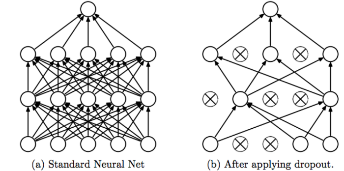

Como método para evitar este sobreajuste usaremos el Dropout el cual eliminará un porcentaje aletorio en cada época para evitar el sobreajuste.

## Flatten

Una vez que se obtiene el mapa destacado agrupado, el siguiente paso es el Flatten. El Flatten implica transformar toda la matriz del feature-map agrupada en una sola columna que luego se une a la red neuronal para su procesamiento.

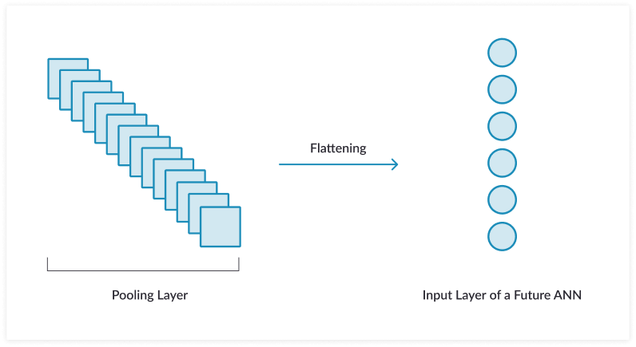

# Función activación

La función de activación es un nodo que se coloca al final o entre las redes neuronales. Ayudan a decidir si la neurona se activará o no

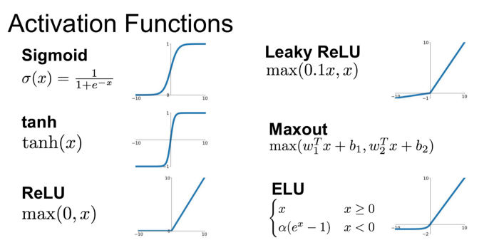

## RELU

Usaremos esta activación en todas las capas salvo en la última.

Es una función lineal por partes que generará la entrada directamente si es positiva; de lo contrario, generará cero. Se ha convertido en la función de activación predeterminada para muchos tipos de redes neuronales porque un modelo que la usa es más fácil de entrenar y, a menudo, logra un mejor rendimiento.

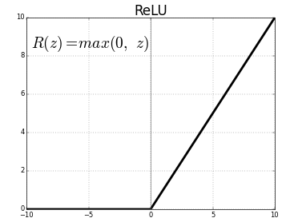

Tiene varias ventajas:

- Simplicidad computacional: en nuestro caso, esto será muy útil.
- Capaz de generar un valor cero y no cercano
- Comportamiento lineal

Son bastante recomendadas para CNN:

- "… how do the non-linearities that follow the filter banks influence the recognition accuracy. The surprising answer is that using a rectifying non-linearity is the single most important factor in improving the performance of a recognition system."— What is the best multi-stage architecture for object recognition?, 2009

## Softmax

En nuestro caso, será la que usemos en la última capa la cual nos dará la probabilidad de una imagen de pertenecer a un grupo.

Parte de una idea similar a la de la Regresión Logística: genera un decimal entre 0 y 1.0 de probabilidad dada una clasificación, es decir, clasifica según la probabilidad de pertenecer a una clase. Esas probabilidades decimales deben sumar 1.0.

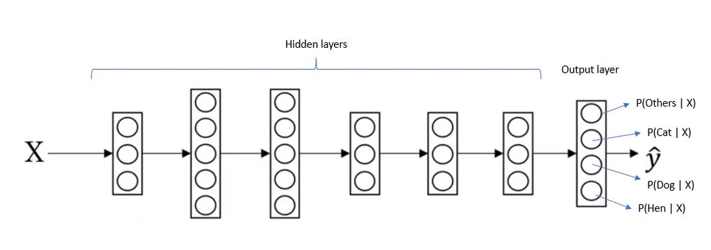

# Optimizador

El mecanismo a través del cual la red se actualizará. basado en los datos que ve y su función de pérdida.

## SGD

El descenso de gradiente estocástico (a menudo abreviado SGD) es un método iterativo para optimizar una función objetivo con propiedades de suavidad adecuadas (por ejemplo, diferenciable o subdiferenciable). Puede considerarse como una aproximación estocástica de la optimización del descenso de gradientes.

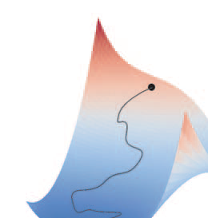

## ADAM

Adam hace uso de un promedio de gradientes pasados que decae exponencialmente. Por tanto, la dirección de las actualizaciones de los parámetros se calcula de forma similar a la del optimizador de impulso.El optimizador de Adam ha tenido una adopción generalizada entre la comunidad de aprendizaje profundo. Actualmente, el optimizador de Adam es el optimizador preferido para usar con modelos de aprendizaje profundo.

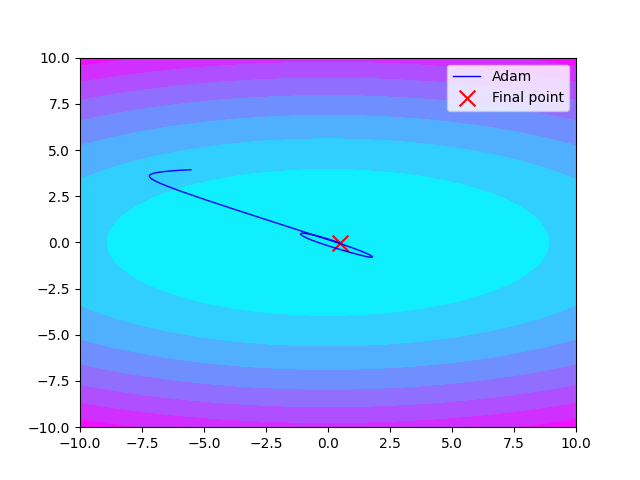

Adam es un algoritmo de optimización que se puede utilizar en lugar del procedimiento de descenso de gradiente estocástico clásico para actualizar los pesos de red de forma iterativa en función de los datos de entrenamiento. Ventajas:

- Fácil de implementar.
- Computacionalmente eficiente.
- Muy adecuado para problemas que son grandes en términos de datos y / o parámetros.
- os hiperparámetros tienen una interpretación intuitiva y normalmente requieren pocos ajustes.

# Función de pérdida

Mide la performance de la red en los datos de entrenamiento y, por lo tanto, le indica la dirección correcta.

## Categorical crossentropy

Modelos con más de dos opciones

## Binary crossentropy

Para modelos con sólo dos opciones